# Business Analytics and Data Mining - Homework 2

Abdellah AitElmouden | Gabriel Abreu | Jered Ataky | Patrick Maloney

3/16/2021

# Objective

# Dataset

The data set was provided to as csv file. On first examination of the data, it looks like the dependent variable class was regressed against several independent variables. The Scored class is the predicted variable, and the scored.probability shows the probability that the scored.class belongs to a class of 1. A further description of the variables is given below:

| Variables | Description |
| --- | --- |
| pregnant | no of times pregnant |
| glucose | plasma glucose concentration |
| diastolic | diastolic blod pressure |
| skinfold | triceps skin fold thickness |
| insulin | serum insulin test |
| bmi | body mass index |
| pedigree | diabetes pedigree function |
| age | age in years |
| class | the actual class for the observation (1: positive for diabetes, 0 negative for diabetes) |
| scored.class | the predicted class for the observation (based on a threshold of 0.5) |
| scored. probability | the predicted probability of success for the observation |

The dataset has three key columns we will use: class, scored.class and scored.probability.

```r
data_url <- "https://raw.githubusercontent.com/aaitelmouden/DATA621/master/Homework2/classification-output-data.csv"
data <- read.csv(data_url)
```

# Confusion Matrix

2. Use the table() function to get the raw confusion matrix for this scored dataset. Make sure you understand the output. In particular, do the rows represent the actual or predicted class? The columns?

```r
data_table <- table(data$class, data$scored.class)

data_table
```

```
##
##       0   1
##   0 119   5
##   1  30  27
```

# R Accuracy Function

3. Write a function that takes the data set as a dataframe, with actual and predicted classifications identified, and returns the accuracy of the predictions.

$$Accuracy = \frac{TP+TN}{TP+FP+TN+FN}$$

```r
calc_accuracy <- function(df){
  TP <- sum(df$class == 1 & data$scored.class == 1)
  TN <- sum(df$class == 0 & data$scored.class == 0)
  (TP + TN)/nrow(df)
}

calc_accuracy(data)
```

```
## [1] 0.8066298
```

# R Classification Error Function

4. Write a function that takes the data set as a dataframe, with actual and predicted classifications identified, and returns the classification error rate of the predictions.

Verify that you get an accuracy and an error rate that sums to one.

```r
calc_error_rate <- function(df){
   FP <- sum(df$class == 0 & data$scored.class == 1)
   FN <- sum(df$class == 1 & data$scored.class == 0)
   (FP + FN)/nrow(df)
}

calc_error_rate(data)
```

```
## [1] 0.1933702
```

# R Precision of the Predictions Function

5. Write a function that takes the data set as a dataframe, with actual and predicted classifications identified, and returns the precision of the predictions.

$$Precision = \frac{TP}{TP+FP}$$

```r
calc_precision <- function(df){
  FP <- sum(df$class == 0 & data$scored.class == 1)
  TP <- sum(df$class == 1 & data$scored.class == 1)
  TP/(TP +FP)
}

calc_precision(data)
```

```
## [1] 0.84375
```

```r
posPredValue(table(data$scored.class, data$class))
```

```
## [1] 0.7986577
```

# R Sensitivity Function

6. Write a function that takes the data set as a dataframe, with actual and predicted classifications identified, and returns the sensitivity of the predictions. Sensitivity is also known as recall.

$$Sensitivity = \frac{TP}{TP+FN}$$

```r
calc_sensitivity <- function(df){
  TP <- sum(df$class == 1 & data$scored.class == 1)
  FN <- sum(df$class == 1 & data$scored.class == 0)
  TP/(TP + FN)
}

calc_sensitivity(data)
```

```
## [1] 0.4736842
```

```r
sensitivity(table(data$scored.class, data$class))
```

```
## [1] 0.9596774
```

# R Specificity Function

7. Write a function that takes the data set as a dataframe, with actual and predicted classifications identified, and returns the specificity of the predictions.

$$Specificity = \frac{TN}{TN+FP}$$

```r
calc_specificity <- function(df){
  FP <- sum(data$class == 0 & data$scored.class == 1)
  TN <- sum(data$class == 0 & data$scored.class == 0)
  TN/(TN + FP)
}

calc_specificity(data)
```

```
## [1] 0.9596774
```

# R F1 Score Function

8. Write a function that takes the data set as a dataframe, with actual and predicted classifications identified, and returns the F1 score of the predictions.

$$F1 \ Score = \frac{2*Precision*Sensitivity}{Precision+Sensitivity}$$

```r
calc_f1 <- function(df){
  (2* calc_precision(df)*calc_sensitivity(df))/(calc_precision(df) + calc_sensitivity(df))
}

calc_f1(data)
```

```
## [1] 0.6067416
```

# F1 score Bounds

9. Before we move on, let’s consider a question that was asked: What are the bounds on the F1 score? Show that the F1 score will always be between 0 and 1. (Hint: If 0 < 𝑎 < 1 and 0 < 𝑏 < 1 then 𝑎𝑏 < 𝑎.)

```r
# To show this, we are going to use uniform distribution with function runif to generate
# random deviates Then run the calc_f1 function and show that min and max values of f1_score
# will always fall are within 0 and 1

# let pre be the precision and sens be the sensitivity (values in percent/between 0 and 1)

pre <- runif(100, min = 0, max = 1)
sens <- runif(100, min = 0, max = 1)

f1_score <- (2 * pre * sens) / (pre + sens)

summary(f1_score)
```

```
##    Min. 1st Qu.  Median    Mean 3rd Qu.    Max.
## 0.01105 0.21470 0.41516 0.39733 0.55960 0.91816
```

# R ROC curve Function

10. Write a function that generates an ROC curve from a data set with a true classification column (class in our example) and a probability column (scored.probability in our example). Your function should return a list that includes the plot of the ROC curve and a vector that contains the calculated area under the curve (AUC). Note that I recommend using a sequence of thresholds ranging from 0 to 1 at 0.01 intervals.

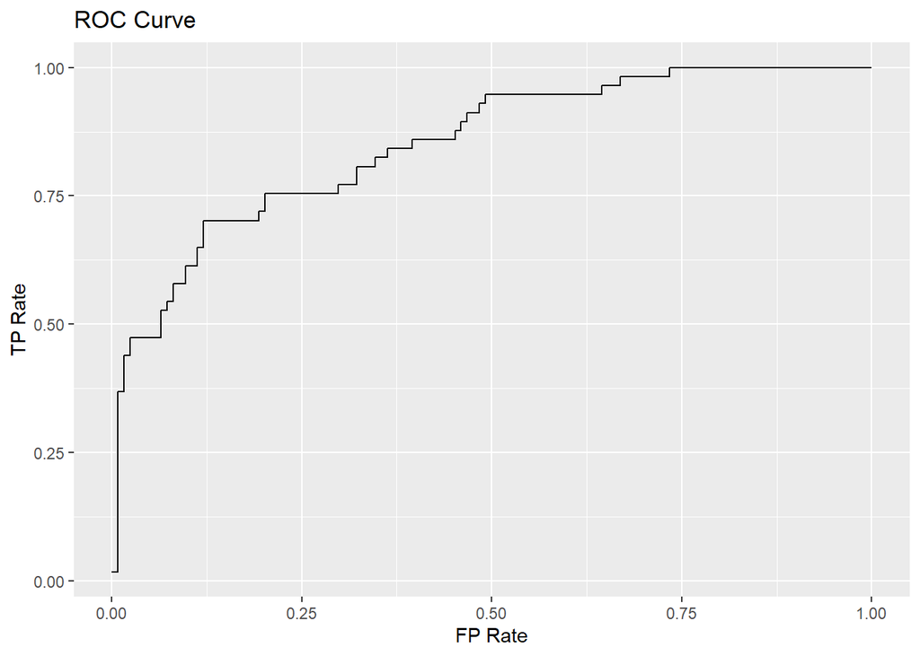

```
##
## $AUC
## [1] 0.8503
```

```r
ROC_function <- function(df){

  # Select the needed variables

  df <- select(df, class, scored.probability)

  x <- df$class
  y<- df$scored.probability

  # Calculate TPR and FPR

  x <- x[order(y, decreasing = TRUE)]

  TPR <- cumsum(x) / sum(x)
  FPR <- cumsum(!x) / sum(!x)

  # Calculate AUC

  # New df

  df <- data.frame(TPR, FPR, x)


  # Inputs already sorted, best scores first

  df_FPR <- c(diff(df$FPR), 0)
  df_TPR <- c(diff(df$TPR), 0)

  #  AUC = total area is the dot product of these vectors

  AUC <- round(sum(df$TPR * df_FPR) + sum(df_TPR * df_FPR)/2, 4)

  # Plot the curve

  g <- ggplot(df, aes(FPR, TPR)) + geom_line() + ggtitle("ROC Curve") +
    xlab("FP Rate") + ylab("TP Rate")


  # Return a list

  return(list(plot=g, AUC=AUC))

}

# Call the function with our data frame

ROC_function(data)
```